# Mini-Project #02: The Business of Show Business

#### 2) Choose 3-5 movies with large numbers of IMDb votes that score poorly on your success metric and confirm that they are indeed of low quality.

Answer:

| Primary Title | WPS | Average Rating | Number of Votes |
| --- | --- | --- | --- |
| 1. Robyn Hood | 8.764990 | 1.0 | 6405 |
| 2. 321 Action | 9.231123 | 1.0 | 10209 |
| 3. The Gringo Papi | 9.467536 | 1.1 | 5468 |
| 4. Decrepit Crescendo | 9.913832 | 1.2 | 3871 |
| 5. What Must Be Done | 9.995746 | 1.1 | 8839 |

**Question 2 Code**

```r
low_movies <- TITLE_RATINGS |>
  filter(numVotes >quantile(TITLE_RATINGS$numVotes, 0.9)) |>
  arrange(weighted_popularity_score) |>
  head(5) |>
  inner_join (TITLE_BASICS, by = "tconst") |>
  select(primaryTitle, weighted_popularity_score, averageRating, numVotes)
```

Conclusion for 1 & 2, the `weighted_popularity_score` (WPS) valid compared with the data and show proper calculation to both highest or lowest amount of votes with scores.

#### 3) Choose a prestige actor or director and confirm that they have many projects with high scores on your success metric.

One of my the most favorite movies is “Inception” so let’s take Cillian Murphy to check the WPS.

Answer:

| Primary Title | WPS | Average Rating | Number of Votes |
| --- | --- | --- | --- |
| 1. The Dark Knight | 134.01527 | 9.0 | 2930213 |
| 2. Inception | 129.98838 | 8.8 | 2601001 |
| 3. Peaky Blinders | 118.12761 | 8.8 | 675758 |
| 4. Batman Begins | 117.17419 | 8.2 | 1606446 |
| 5. Oppenheimer | 112.84997 | 8.3 | 803217 |

**Question 3 Code**

```r
#finding cillian murphy id in the dataset
cillian_murphy <- NAME_BASICS |>
  filter(primaryName == "Cillian Murphy") |>
  select(nconst, primaryName)

successful_actor <- TITLE_PRINCIPALS |>
  filter(nconst == "nm0614165") |>
  inner_join(TITLE_RATINGS, by = "tconst") |>
  arrange(desc(weighted_popularity_score)) |>
  inner_join(TITLE_BASICS, by = "tconst") |>
  select(primaryTitle, weighted_popularity_score, averageRating, numVotes)
```

#### 4) Perform at least one other form of ‘spot check’ validation.

The best way to cut unpopular vs popular movies is to verify with minimum and maximum functions. And do a quick check where are the most points are.

Min: 4.62 Max: 138.8

**Question 4 Code**

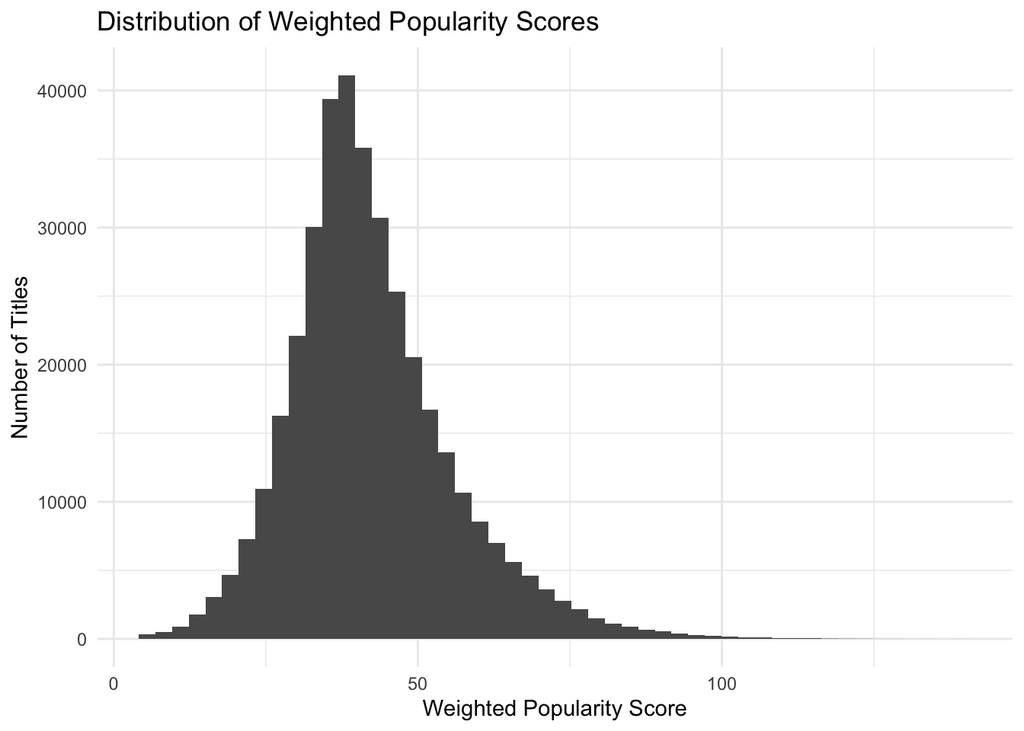

```r
TITLE_RATINGS <- TITLE_RATINGS |>
  mutate(weighted_popularity_score = averageRating * log(numVotes + 1))

min_score <- min(TITLE_RATINGS$weighted_popularity_score, na.rm = TRUE)
max_score <- max(TITLE_RATINGS$weighted_popularity_score, na.rm = TRUE)

TITLE_RATINGS |>
  ggplot(aes(x = weighted_popularity_score)) +
  geom_histogram(bins = 50) +
  xlab("Weighted Popularity Score") +
  ylab("Number of Titles") +
  ggtitle("Distribution of Weighted Popularity Scores") +
  theme_minimal()
```

#### 5) Come up with a numerical threshold for a project to be a ‘success’; that is, determine a value v such that movies above v are all “solid” or better.

The 90th percentile corresponds to a 59.87, so we will set a threshold value not lower than 59 to capture the truly successful movies.

**Question 5 - Code**

```r
quantiles <- quantile(TITLE_RATINGS$weighted_popularity_score, probs = seq(0, 1, 0.1), na.rm = TRUE)
print(quantiles)
```

```
        0%        10%        20%        30%        40%        50%        60%
  4.624973  27.429451  32.152835  35.240087  37.728284  40.266733  43.192933
       70%        80%        90%       100%
 46.804929  51.731514  59.864480 138.772311
```

**Question 5 - Code**

```r
success_threshold <- 59
```

#### Task 4. Trends in Success Over Time

Alright, now we can check data more with a threshold set to find successful plots that attract the audience.

**Task 4 - Data Prep**

```r
TITLE_RATINGS <- TITLE_RATINGS |>
  mutate(weighted_popularity_score = averageRating * log(numVotes + 1))
titles_data <- TITLE_BASICS |>
  inner_join(TITLE_RATINGS, by = "tconst")
movies_data <- titles_data |>
  filter(titleType == "movie")
movies_data <- movies_data |>
  mutate(startYear = as.numeric(startYear)) |>
  filter(!is.na(startYear) & startYear >= 1900 & startYear <= 2024)
movies_data <- movies_data |>
  separate_rows(genres, sep = ",")
movies_data <- movies_data |>
  filter(genres != "\\N")
success_threshold <- 59
movies_data <- movies_data |>
  mutate(is_success = ifelse(weighted_popularity_score >= success_threshold, TRUE, FALSE))
#creating a decade
movies_data <- movies_data |>
  mutate(decade = floor(startYear / 10) * 10)

# a) Count successes by genre and decade
genre_decade_successes <- movies_data |>
  filter(is_success) |>
  group_by(decade, genres) |>
  summarise(success_count = n(), .groups = 'drop')
# b) Total number of movies by genre and decade
genre_decade_totals <- movies_data |>
  group_by(decade, genres) |>
  summarise(total_count = n(), .groups = 'drop')
# c) Calculate success rate
genre_decade_stats <- genre_decade_successes |>
  inner_join(genre_decade_totals, by = c("decade", "genres")) |>
  mutate(success_rate = success_count / total_count)
```

#### 1) What was the genre with the most “successes” in each decade?

Previously, we assigned the threshold and further analyses will be based on this “success metric”.

Spoiler: People love **Drama!**

| Decade | Genre | Success Count |
| --- | --- | --- |
| 1910 | Drama | 3 |
| 1920 | Drama | 51 |
| 1930 | Drama | 133 |
| 1940 | Drama | 237 |
| 1950 | Drama | 341 |
| 1960 | Drama | 424 |
| 1970 | Drama | 469 |
| 1980 | Drama | 574 |
| 1990 | Drama | 1093 |
| 2000 | Drama | 1808 |
| 2010 | Drama | 2446 |
| 2020 | Drama | 975 |

**Question 1 - Code**

```r
top_genres_per_decade <- genre_decade_successes |>
  group_by(decade) |>
  top_n(1, wt = success_count) |>
  arrange(decade)
```

Plotting over time with new `gganimate` knowledge.

**Question 1 - Moving plot**

```r
if (!require(gganimate)) install.packages("gganimate")
if (!require(gifski)) install.packages("gifski")
if (!require(av)) install.packages("av")
if (!require(scales)) install.packages("scales")

# Load libraries
library(ggplot2)
library(gganimate)
library(gifski)
library(av)
library(scales)
library(dplyr)
library(tidyr)
#I was doing this code separately in R, so you will see some variables we did before
movies_data <- movies_data |>
  mutate(is_success = ifelse(weighted_popularity_score >= success_threshold, TRUE, FALSE))

genre_decade_successes <- movies_data |>
  filter(is_success) |>
  group_by(decade, genres) |>
  summarise(success_count = n(), .groups = 'drop')

top_genres_overall <- genre_decade_successes |>
  group_by(genres) |>
  summarise(total_successes = sum(success_count), .groups = 'drop') |>
  arrange(desc(total_successes)) |>
  head(10) |>
  pull(genres)

plot_data <- genre_decade_successes |>
  filter(genres %in% top_genres_overall)

# Collapsed animated plot as it breaks during rendering, works locally well!
# animation <- ggplot(plot_data, aes(x = reorder(genres, success_count), y = success_count, fill = genres)) +
#   geom_bar(stat = "identity") +
#   coord_flip() +
#   labs(title = "Number of Successful Movies by Genre in {closest_state}",
#        x = "Genre",
#        y = "Number of Successful Movies") +
#   theme_minimal() +
#   theme(legend.position = "none",
#         plot.title = element_text(size = 16, face = "bold")) +
#   transition_states(decade, transition_length = 2, state_length = 1) +
#   ease_aes('cubic-in-out')
#
# # Render
# animate(animation, renderer = gifski_renderer(), width = 800, height = 600)
# anim_save("genre_successes.gif", animation = last_animation())
```

[figure not shown]

Genre Successes Animation

#### 2) What genre consistently has the most “successes”? What genre used to reliably produced “successes” and has fallen out of favor?

Answer:

| Genres | Decades with success | Total successes |
| --- | --- | --- |
| Drama | 12 | 8554 |
| Action | 12 | 2767 |
| Crime | 12 | 2639 |
| Romance | 12 | 2419 |
| Adventure | 12 | 1826 |
| History | 12 | 687 |
| War | 12 | 446 |
| Comedy | 11 | 4379 |
| Thriller | 11 | 1809 |
| Biography | 11 | 1146 |
| Mystery | 11 | 1143 |
| Horror | 11 | 1012 |
| Documentary | 11 | 883 |
| Fantasy | 11 | 762 |
| Animation | 11 | 632 |

**Question 2 - Code**

```r
genre_decade_presence <- genre_decade_successes |>
  group_by(genres) |>
  summarise(decades_with_success = n_distinct(decade), .groups = 'drop')

total_successes_per_genre <- genre_decade_successes |>
  group_by(genres) |>
  summarise(total_successes = sum(success_count), .groups = 'drop')

genre_consistency <- genre_decade_presence |>
  inner_join(total_successes_per_genre, by = "genres") |>
  arrange(desc(decades_with_success), desc(total_successes))
```

#### 3) What genre has produced the most “successes” since 2010? Does it have the highest success rate or does it only have a large number of successes because there are many productions in that genre?

**What genre has produced the most “successes” since 2010?**

Answer: **Drama** has produced the most “successes” since 2010, with **3,421** successful movies.

**Does it have the highest success rate or does it only have a large number of successes because there are many productions in that genre?**

Answer: Drama does not have the highest success rate. Its large number of successes is primarily due to the high number of productions in that genre. The success rate for Drama is **12%**, which is lower than genres like Biography **22.4%** and Adventure **20.3%**.

**Question 3 - Code**

```r
movies_since_2010 <- movies_data |>
  filter(startYear >= 2010)

successes_since_2010 <- movies_since_2010 |>
  filter(is_success) |>
  group_by(genres) |>
  summarise(success_count = n(), .groups = 'drop')

total_since_2010 <- movies_since_2010 |>
  group_by(genres) |>
  summarise(total_count = n(), .groups = 'drop')

genre_success_rate_since_2010 <- successes_since_2010 |>
  inner_join(total_since_2010, by = "genres") |>
  mutate(success_rate = success_count / total_count) |>
  arrange(desc(success_count))
```

Here’s a plot:

**Question 3 - Code**

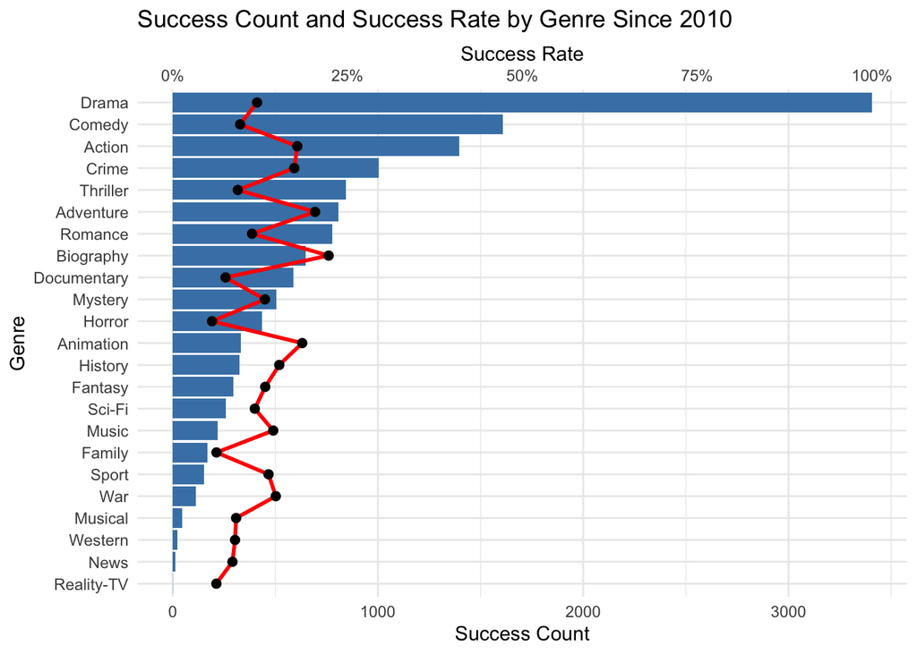

```r
library(ggplot2)
library(scales)

ggplot(genre_success_rate_since_2010, aes(x = reorder(genres, success_count), y = success_count)) +
  geom_bar(stat = "identity", fill = "steelblue") +
  geom_line(aes(y = success_rate * max(success_count), group = 1), color = "red", size = 1) +
  geom_point(aes(y = success_rate * max(success_count)), color = "black", size = 2) +
  scale_y_continuous(
    name = "Success Count",
    sec.axis = sec_axis(~ . / max(genre_success_rate_since_2010$success_count), name = "Success Rate", labels = percent_format(accuracy = 1))
  ) +
  labs(
    title = "Success Count and Success Rate by Genre Since 2010",
    x = "Genre"
  ) +
  coord_flip() +
  theme_minimal()
```

#### 4) What genre has become more popular in recent years?

Answer: The **News** genre has become **x10 times** more popular in recent years, exhibiting the highest growth rate among all genres according to the provided data.

**Question 4 - Code**

```r
genre_decade_totals_all <- movies_data |>
  group_by(decade, genres) |>
  summarise(total_count = n(), .groups = 'drop')

# Total movies per genre from previous decade
genre_growth <- genre_decade_totals_all |>
  arrange(genres, decade) |>
  group_by(genres) |>
  mutate(previous_total = lag(total_count),
         growth = (total_count - previous_total) / previous_total) |>
  ungroup()

# Recent decades from 1990 onwards
recent_genre_growth <- genre_growth |>
  filter(decade >= 1990 & !is.na(growth))

top_growing_genres <- recent_genre_growth |>
  arrange(desc(growth)) |>
  head(10)

print(top_growing_genres)
```

```
# A tibble: 10 × 5
   decade genres      total_count previous_total growth
    <dbl> <chr>             <int>          <int>  <dbl>
 1   2010 News                147             12  11.2
 2   2000 News                 12              2   5
 3   2000 Documentary        2225            554   3.02
 4   2010 Biography          2097            677   2.10
 5   2010 History            1551            512   2.03
 6   2020 Reality-TV           12              4   2
 7   2000 Sport               396            152   1.61
 8   2010 Documentary        5551           2225   1.49
 9   2000 Music               653            268   1.44
10   2000 Horror             2180            898   1.43
```

#### **Task 5. Key Personnel**

Let’s prapare the data to get at least 2 best actors and 1 director.

**Task 5 - Code**

```r
TITLE_RATINGS <- TITLE_RATINGS |>
  mutate(weighted_popularity_score = averageRating * log(numVotes + 1))

# Merge TITLE_BASICS, TITLE_RATINGS, and TITLE_PRINCIPALS
movies_data <- TITLE_BASICS |>
  inner_join(TITLE_RATINGS, by = "tconst") |>
  inner_join(TITLE_PRINCIPALS, by = "tconst") |>
  filter(category %in% c("actor", "actress", "director"))

movies_data <- movies_data |>
  mutate(startYear = as.numeric(startYear)) |>
  filter(!is.na(startYear) & startYear >= 2010 & titleType == "movie")

# Join with NAME_BASICS to get actor and director names
movies_data <- movies_data |>
  inner_join(NAME_BASICS, by = "nconst") |>
  select(nconst, primaryName, category, tconst, primaryTitle, startYear, genres, weighted_popularity_score)

#FOR ACTORS/ACTRESSES ONLY
# Calculate average success metric for actors and actresses
actor_success <- movies_data |>
  filter(category %in% c("actor", "actress")) |>
  group_by(nconst, primaryName) |>
  summarise(
    average_success = mean(weighted_popularity_score, na.rm = TRUE),
    total_movies = n(),
    .groups = 'drop'
  ) |>
  filter(total_movies >= 3)  # Consider actors with at least 3 movies
#DIRECTORS ONLY
# Filter for directors
director_data <- TITLE_CREW |>
  separate_rows(directors, sep = ",") |>
  rename(nconst = directors) |>
  inner_join(TITLE_BASICS, by = "tconst") |>
  inner_join(TITLE_RATINGS, by = "tconst") |>
  mutate(startYear = as.numeric(startYear)) |>
  filter(!is.na(startYear) & startYear >= 2010 & titleType == "movie") |>
  inner_join(NAME_BASICS, by = "nconst") |>
  select(nconst, primaryName, tconst, primaryTitle, startYear, genres, weighted_popularity_score)
```

We will concentrate on two genres Action and War to get our top actors and directors.

**Task 5 - Code**

```r
# Calculate average success metric for directors
director_success <- director_data |>
  group_by(nconst, primaryName) |>
  summarise(
    average_success = mean(weighted_popularity_score, na.rm = TRUE),
    total_movies = n(),
    .groups = 'drop'
  ) |>
  filter(total_movies >= 2)  # Consider directors with at least 2 movies

#TOP ACTORS
preferred_genres <- c("Action", "War")

# Filter movies in preferred genres
actors_in_genres <- movies_data |>
  filter(category %in% c("actor", "actress")) |>
  separate_rows(genres, sep = ",") |>
  filter(genres %in% preferred_genres)

# Average success for actors in preferred genres
actor_success_genre <- actors_in_genres |>
  group_by(nconst, primaryName) |>
  summarise(
    average_success = mean(weighted_popularity_score, na.rm = TRUE),
    total_movies = n(),
    .groups = 'drop'
  ) |>
  filter(total_movies >= 2)  # At least 2 movies in preferred genres

# Top 5 actors
top_actors <- actor_success_genre |>
  arrange(desc(average_success)) |>
  head(5)
# print(top_actors)

#TOP DIRECTOR
# Filter director movies in preferred genres
directors_in_genres <- director_data |>
  separate_rows(genres, sep = ",") |>
  filter(genres %in% preferred_genres)

# Average success for directors in preferred genres
director_success_genre <- directors_in_genres |>
  group_by(nconst, primaryName) |>
  summarise(
    average_success = mean(weighted_popularity_score, na.rm = TRUE),
    total_movies = n(),
    .groups = 'drop'
  ) |>
  filter(total_movies >= 1)  # At least 1 movie in preferred genres

top_directors <- director_success_genre |>
  arrange(desc(average_success)) |>
  head(3)
# print(top_directors)
```

Answer:

Top Actors

| Primary Name | Average Success | Total Movies |
| --- | --- | --- |
| Leonardo DiCaprio | 120 | 2 |
| Timothée Chalamet | 111 | 2 |
| Don Cheadle | 108 | 10 |
| Robert Downey Jr. | 107 | 15 |
| Mark Ruffalo | 107 | 12 |

Answer:

Top Directors

| Primary Name | Average Success | Total Movies |
| --- | --- | --- |
| Christopher Nolan | 114 | 4 |
| Rodney Rothman | 113 | 1 |
| Bob Persichetti | 113 | 1 |

I’ve combined directors and actors successes scores and highlighted selected ones.

**Bar plot**

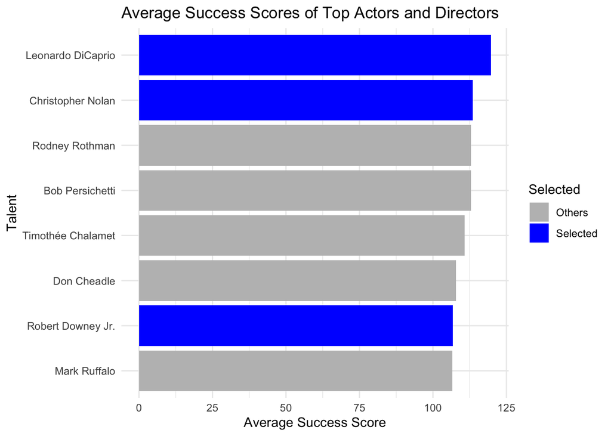

```r
library(ggplot2)
library(dplyr)

# Get top 5 actors and top 3 directors
top_actors <- actor_success_genre %>%
  arrange(desc(average_success)) %>%
  head(5)

top_directors <- director_success_genre %>%
  arrange(desc(average_success)) %>%
  head(3)

plot_data <- bind_rows(
  top_actors %>% mutate(Talent = "Actor"),
  top_directors %>% mutate(Talent = "Director")
)

# Highlight selected talents
selected_names <- c("Leonardo DiCaprio", "Robert Downey Jr.", "Christopher Nolan")
plot_data <- plot_data %>%
  mutate(Selected = ifelse(primaryName %in% selected_names, "Selected", "Others"))

# Create the bar chart
ggplot(plot_data, aes(x = reorder(primaryName, average_success), y = average_success, fill = Selected)) +
  geom_bar(stat = "identity") +
  coord_flip() +
  labs(
    title = "Average Success Scores of Top Actors and Directors",
    x = "Talent",
    y = "Average Success Score"
  ) +
  scale_fill_manual(values = c("Selected" = "blue", "Others" = "grey")) +
  theme_minimal()
```

#### Task 6: Finding a Classic Movie to Remake

[Lawrence of Arabia](https://www.imdb.com/title/tt0056172/) is an epic classic that presents a profound and captivating narrative, making it an ideal candidate for a modern remake. IMDb rating of 8.3 and a substantial number of ratings, reflecting its enduring popularity. There has been no remake of this classic action and war film in the past 25 years. Since the original actors and director are deceased, we can proceed with a new cast featuring Leonardo DiCaprio and Robert Downey Jr., directed by Christopher Nolan. To move forward, we need to clarify and secure the legal rights from Columbia Pictures, the current rights holder.

#### **Task 7: Write and Deliver Your Pitch**

**Elevator Pitch:**

Christopher Nolan, renowned for his visionary storytelling in films like “Inception” and “Dunkirk”, will direct this ambitious remake. Leading the cast, Leonardo DiCaprio will embody the complex character of T.E. Lawrence, bringing depth and nuance to the role. Alongside him, Robert Downey Jr. will add his charisma and talent to a pivotal supporting role, enhancing the film’s appeal.

With this exceptional team, we aim to create a cinematic masterpiece that honors the original while captivating modern audiences. Securing the rights from Columbia Pictures will allow us to proceed, and with your approval, we can begin this exciting journey.

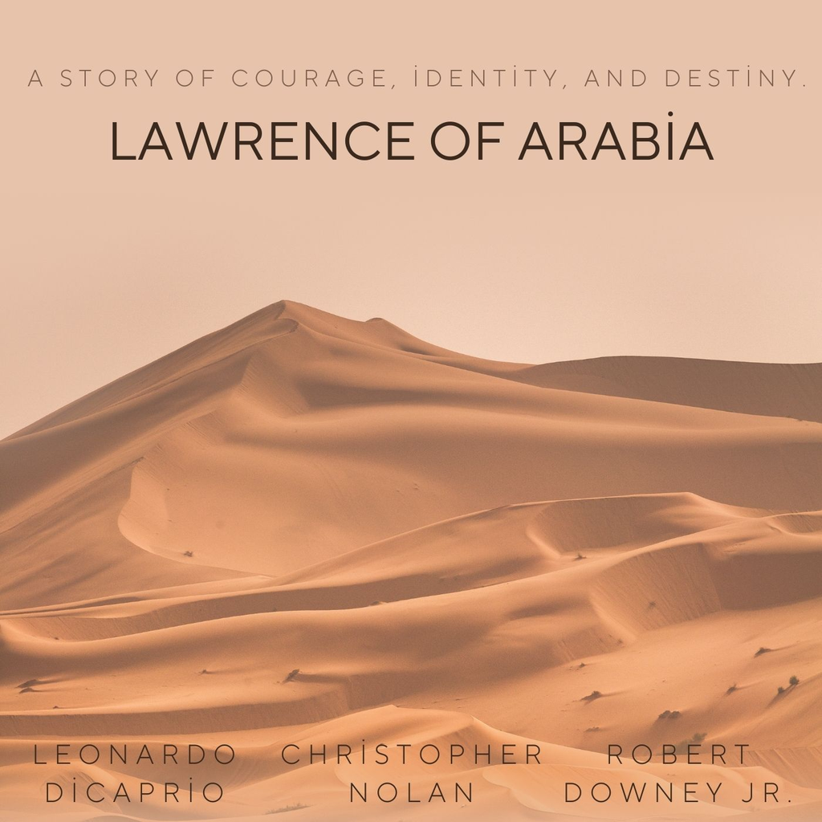

**Classic 90’s Style Teaser:**

> From director Christopher Nolan, the visionary mind behind “Inception” and “Dunkirk”;

> And from actor Leonardo DiCaprio, beloved star of “The Revenant”;

> And from actor Robert Downey Jr., Hollywood icon of action and war films;

> Comes the timeless tale “Lawrence of Arabia”.

> A story of courage, identity, and destiny.

> Coming soon to a theater near you.